# *Practical Lab 6 - Logistic Regression*

*The goal is to classify the species of an Iris flower given the dimensions of parts of the flower. The classification is binary, there are two classes: virginica and non-virginica.*

```python
import pandas as pd
from sklearn.datasets import load_iris
import seaborn as sns
import matplotlib.pyplot as plt

# Loading Iris dataset
iris = load_iris(as_frame=True)

# Selecting only the petal width feature
X = iris.data[["petal width (cm)"]].values

# Defining target variable with two classes: virginica and non-virginica
y = iris.target_names[iris.target] == 'virginica'

# Creating a DataFrame using the data and feature names
df = pd.DataFrame(data=iris.data, columns=iris.feature_names)

# Adding the target variable 'Species' to the DataFrame
df['Species'] = iris.target_names[iris.target]
```

## *Data Visualization*

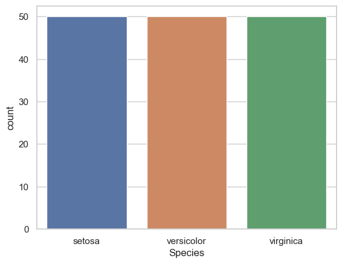

```python
sns.countplot(x = 'Species', data=df)
```

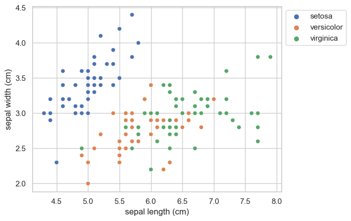

```python
sns.scatterplot(x='sepal length (cm)', y='sepal width (cm)', hue='Species', data=df)

# Placing legend outside the figure
plt.legend(bbox_to_anchor=(1, 1), loc=2)
plt.show()
```

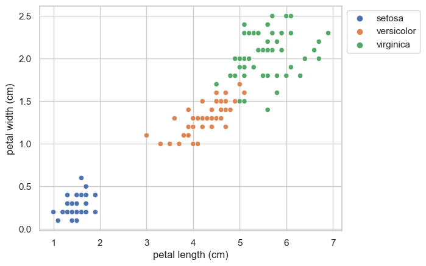

```python
sns.scatterplot(x='petal length (cm)', y='petal width (cm)', hue='Species', data=df)

# Placing legend outside the figure
plt.legend(bbox_to_anchor=(1, 1), loc=2)
plt.show()
```

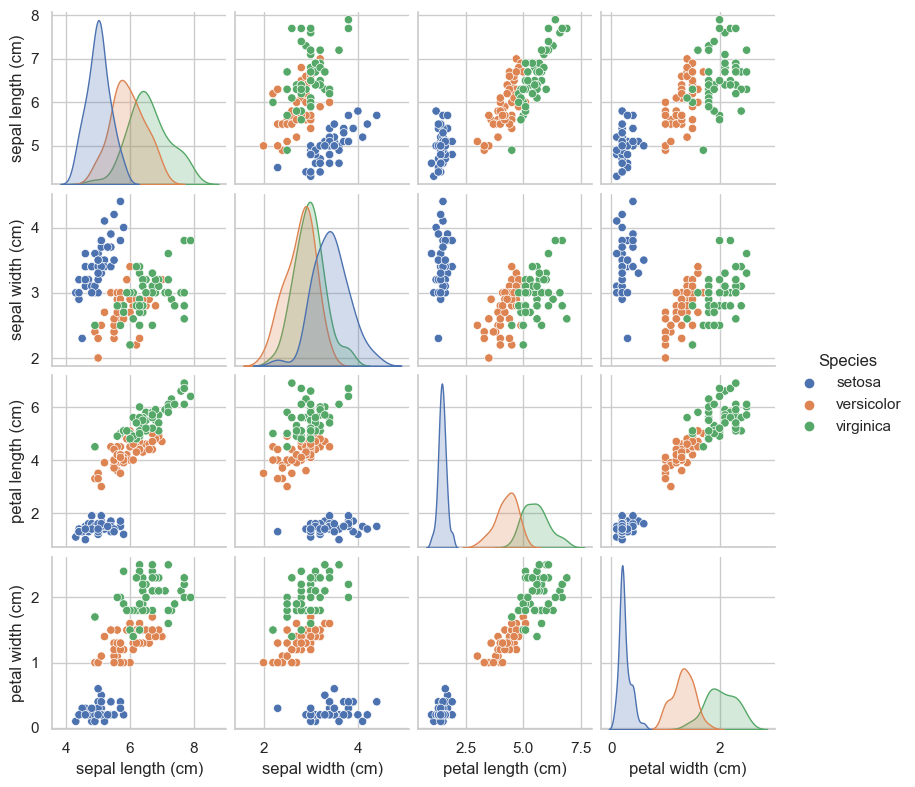

```python
sns.pairplot(df.drop([], axis=1), hue='Species', height=2)
```

```python
df.head()
```

|  | sepal length (cm) | sepal width (cm) | petal length (cm) | petal width (cm) | Species |
| --- | --- | --- | --- | --- | --- |
| 0 | 5.1 | 3.5 | 1.4 | 0.2 | setosa |
| 1 | 4.9 | 3.0 | 1.4 | 0.2 | setosa |
| 2 | 4.7 | 3.2 | 1.3 | 0.2 | setosa |
| 3 | 4.6 | 3.1 | 1.5 | 0.2 | setosa |
| 4 | 5.0 | 3.6 | 1.4 | 0.2 | setosa |

```python
# Using describe() method to get the summary statistics for the entire dataset
print("\nSummary statistics for the dataset:")
df.describe()
```

```
Summary statistics for the dataset:
```

|  | sepal length (cm) | sepal width (cm) | petal length (cm) | petal width (cm) |
| --- | --- | --- | --- | --- |
| count | 150.000000 | 150.000000 | 150.000000 | 150.000000 |
| mean | 5.843333 | 3.057333 | 3.758000 | 1.199333 |
| std | 0.828066 | 0.435866 | 1.765298 | 0.762238 |
| min | 4.300000 | 2.000000 | 1.000000 | 0.100000 |
| 25% | 5.100000 | 2.800000 | 1.600000 | 0.300000 |
| 50% | 5.800000 | 3.000000 | 4.350000 | 1.300000 |
| 75% | 6.400000 | 3.300000 | 5.100000 | 1.800000 |
| max | 7.900000 | 4.400000 | 6.900000 | 2.500000 |

## *Exploratory Data Analysis*

*Showing one Histogram per feature*

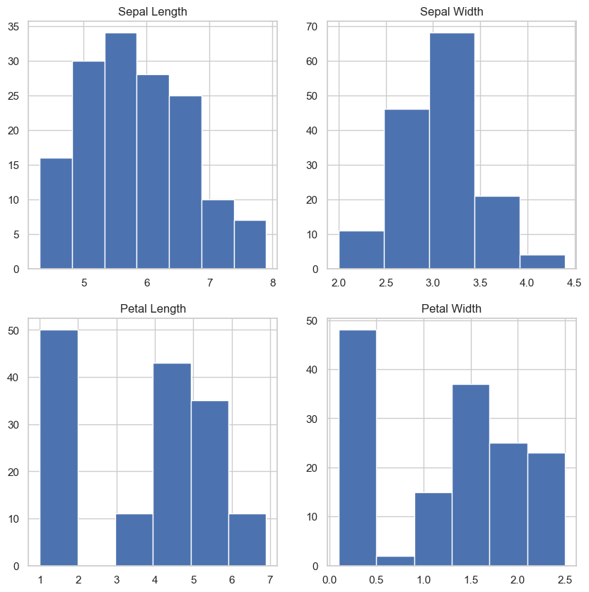

```python
# Plotting histograms
fig, axes = plt.subplots(2, 2, figsize=(10, 10))

axes[0, 0].set_title("Sepal Length")
axes[0, 0].hist(df['sepal length (cm)'], bins=7)

axes[0, 1].set_title("Sepal Width")
axes[0, 1].hist(df['sepal width (cm)'], bins=5)

axes[1, 0].set_title("Petal Length")
axes[1, 0].hist(df['petal length (cm)'], bins=6)

axes[1, 1].set_title("Petal Width")
axes[1, 1].hist(df['petal width (cm)'], bins=6)

plt.show()
```

*Correlation matrix between the four features*

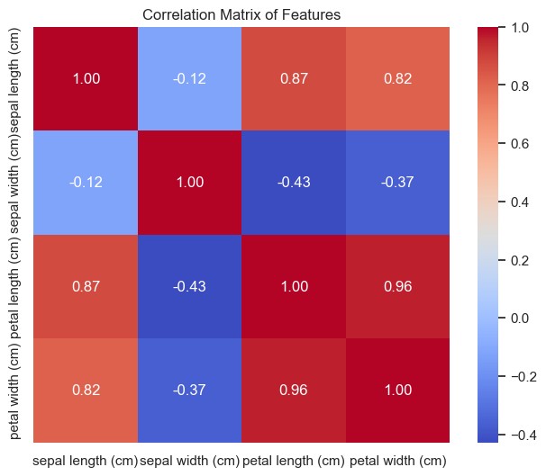

```python
# Plotting the correlation matrix using seaborn
plt.figure(figsize=(8, 6))
sns.heatmap(correlation_matrix, annot=True, cmap='coolwarm', fmt=".2f", square=True)
plt.title('Correlation Matrix of Features')
plt.show()
```

## *Adding additional graphs from Kaggle*

### ➼ [Kaggle Reference for Violin Plots](https://www.kaggle.com/code/jchen2186/machine-learning-with-iris-dataset)

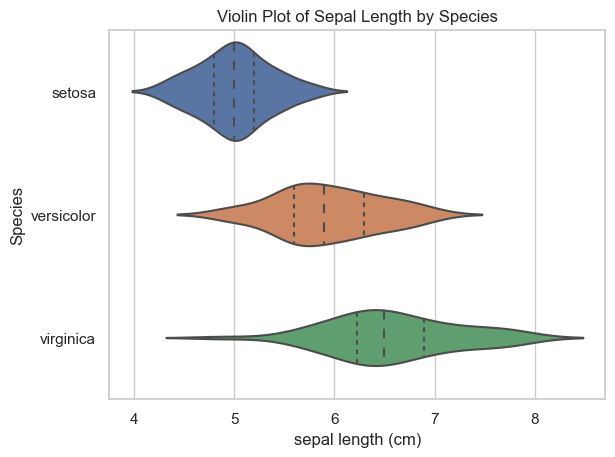

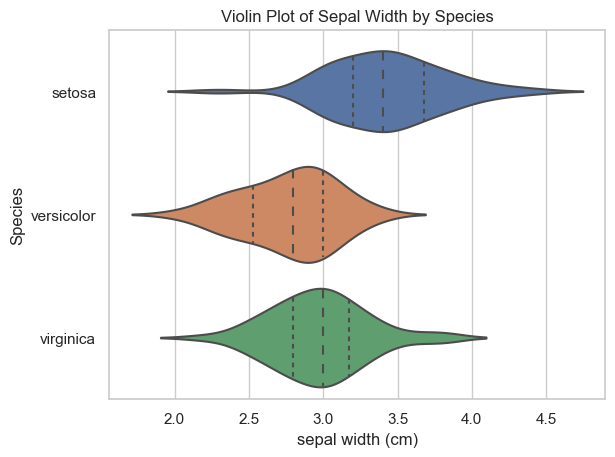

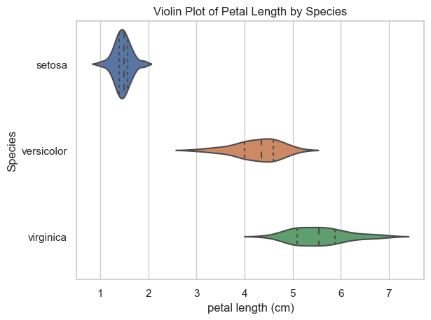

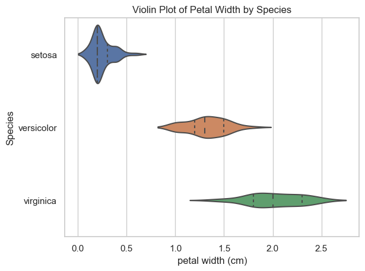

```python
# Plotting violin plots for each feature, separated by species
g = sns.violinplot(y='Species', x='sepal length (cm)', data=df, inner='quartile')
plt.title('Violin Plot of Sepal Length by Species')
plt.show()

g = sns.violinplot(y='Species', x='sepal width (cm)', data=df, inner='quartile')
plt.title('Violin Plot of Sepal Width by Species')
plt.show()

g = sns.violinplot(y='Species', x='petal length (cm)', data=df, inner='quartile')
plt.title('Violin Plot of Petal Length by Species')
plt.show()

g = sns.violinplot(y='Species', x='petal width (cm)', data=df, inner='quartile')
plt.title('Violin Plot of Petal Width by Species')
plt.show()
```

*Feature Distribution by Species:*

*The violin plots visually depict the distribution of each feature (sepal length, sepal width, petal length, petal width) for each species of iris flower.* *By observing the width and shape of the violins, we can gain insights into the variability and distribution of each feature within different species.* *For instance, we might notice that the distribution of petal length and petal width for the virginica species tends to have a broader range compared to other species, indicating higher variability in these features among virginica flowers.*

*Feature Separability:*

*The violin plots can help us assess the degree of separability between species based on different features* *If there is significant overlap between the violins of different species for a particular feature, it suggests that this feature might not be very effective in distinguishing between species.* *Conversely, if the violins are well-separated or exhibit distinct shapes for different species, it indicates that the corresponding feature is likely to be informative for species classification.* *For instance, if the violins for petal length and petal width are distinctly different for each species, it suggests that these features are highly informative for species classification.*

### ➼ [Kaggle Reference for Box Plots](https://www.kaggle.com/code/praneshchowdhury/iris-flower-data-visualization)

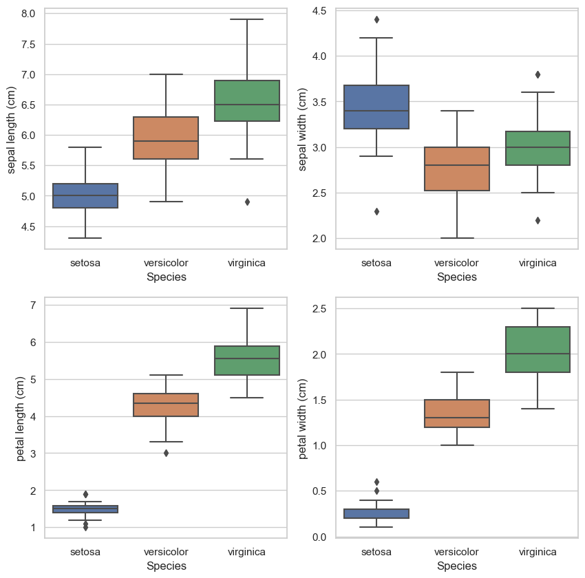

```python
def graph(y):
    sns.boxplot(x="Species", y=y, data=df)

plt.figure(figsize=(10, 10))

# adding the subplot at the specified
# grid position
plt.subplot(221)
graph('sepal length (cm)')

plt.subplot(222)
graph('sepal width (cm)')

plt.subplot(223)
graph('petal length (cm)')

plt.subplot(224)
graph('petal width (cm)')

plt.show()
```

*Distribution of Features by Species:*

*The box plots visualize the distribution of each feature (sepal length, sepal width, petal length, petal width) for each species of iris flower.* *By comparing the box plots across different species, we can observe differences in the central tendency, variability, and presence of outliers for each feature.* *For instance, if the box plot for sepal length shows that the median (middle line of the box) for virginica species is higher than for other species, it indicates that virginica flowers tend to have longer sepals compared to other species.*

*Comparison of Feature Distributions:*

*Box plots allow for a direct comparison of the distributions of different features within each species.* *By examining the position, spread, and shape of the boxes (interquartile range), whiskers (range of data), and outliers, we can identify features that exhibit significant differences between species and those that have similar distributions.* *For example, if the interquartile range (IQR) of petal length for one species is much larger than for others, it suggests that this feature varies more within that species.*

*Identification of Outliers:*

*Box plots provide a visual representation of outliers within each feature's distribution.* *Outliers are data points that fall outside the whiskers of the box plot, indicating values that are significantly different from the rest of the data.* *By inspecting the box plots, we can identify potential outliers for each feature within each species, which may be indicative of unusual or extreme values.* *For instance, if we observe outliers in sepal width for a particular species, it could indicate some abnormality or distinct trait in that species' sepal width distribution.* *These insights derived from the box plots can help in understanding the characteristics of different species of iris flowers and their distinguishing features, which is valuable for classification and further analysis tasks.*

```python
from sklearn.model_selection import train_test_split
from sklearn.linear_model import LogisticRegression
from sklearn.metrics import accuracy_score

# Splitting the data into train, validation, and test sets
X_train_val, X_test, y_train_val, y_test = train_test_split(X, y, test_size=15, random_state=42)
X_train, X_val, y_train, y_val = train_test_split(X_train_val, y_train_val, test_size=15, random_state=42)


# Defining logistic regression models with different numbers of features
models = {
    1: LogisticRegression(),
    2: LogisticRegression(),
    3: LogisticRegression(),
    4: LogisticRegression()
}

# Training each model on the training set
for num_features, model in models.items():
    model.fit(X_train[:, :num_features], y_train)
```

```python
test_results = np.c_[
    X_test,
    model.predict_proba(X_test)[:,0],
    model.predict_proba(X_test)[:,1],
    model.predict(X_test),
    y_test,
    ]

columns=[
    'petal_width_cm',
    'negative_class_probability',
    'positive_class_probability',
    'y_pred',
    'y_test',
    ]

df = pd.DataFrame(test_results, columns=columns)

# sorting the dataframe by petal_width_cm
df = df.sort_values(by=['petal_width_cm'])

df.head(-1)
```

|  | petal_width_cm | negative_class_probability | positive_class_probability | y_pred | y_test |
| --- | --- | --- | --- | --- | --- |
| 11 | 0.1 | 0.997511 | 0.002489 | 0.0 | 0.0 |
| 13 | 0.1 | 0.997511 | 0.002489 | 0.0 | 0.0 |
| 12 | 0.2 | 0.996322 | 0.003678 | 0.0 | 0.0 |
| 1 | 0.3 | 0.994568 | 0.005432 | 0.0 | 0.0 |
| 14 | 0.3 | 0.994568 | 0.005432 | 0.0 | 0.0 |
| 5 | 0.4 | 0.991984 | 0.008016 | 0.0 | 0.0 |
| 0 | 1.2 | 0.843541 | 0.156459 | 0.0 | 0.0 |
| 9 | 1.2 | 0.843541 | 0.156459 | 0.0 | 0.0 |
| 6 | 1.3 | 0.784677 | 0.215323 | 0.0 | 0.0 |
| 4 | 1.4 | 0.711247 | 0.288753 | 0.0 | 0.0 |
| 3 | 1.5 | 0.624751 | 0.375249 | 0.0 | 0.0 |
| 8 | 1.5 | 0.624751 | 0.375249 | 0.0 | 0.0 |
| 10 | 2.0 | 0.190208 | 0.809792 | 1.0 | 1.0 |
| 2 | 2.3 | 0.067628 | 0.932372 | 1.0 | 1.0 |

```
Model with 1 features:
    Instance Number  Probability of Predicting Virginica  Predicted Label
0                 1                             0.932372             True  \
1                 2                             0.003678            False
2                 3                             0.288753            False
3                 4                             0.003678            False
4                 5                             0.005432            False
5                 6                             0.215323            False
6                 7                             0.932372             True
7                 8                             0.215323            False
8                 9                             0.215323            False
9                10                             0.660447             True
10               11                             0.078119            False
11               12                             0.078119            False
12               13                             0.375249            False
```

[output cut: 131 more lines]

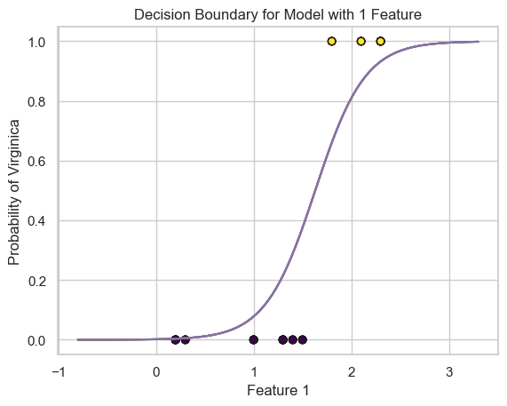

```python
# Evaluating models on the validation set
for num_features, model in models.items():
    # Predict probabilities and labels
    y_prob_val = model.predict_proba(X_val[:, :num_features])[:, 1]
    y_pred_val = model.predict(X_val[:, :num_features])

    # Creating a table for each model
    table_data = {
        'Instance Number': np.arange(1, len(X_val) + 1),
        'Probability of Predicting Virginica': y_prob_val,
        'Predicted Label': y_pred_val,
        'Ground Truth': y_val
    }
    table_df = pd.DataFrame(table_data)

    # Printing the table and calculate validation accuracy
    print(f"Model with {num_features} features:")
    print(table_df)
    accuracy = accuracy_score(y_val, y_pred_val)
    print(f"Validation accuracy: {accuracy}\n")

# Plotting the decision boundary for three models (with 1, 2, and 3 features)
def plot_decision_boundary(model, X, y):
    if X.shape[1] == 1:
        x_min, x_max = X[:, 0].min() - 1, X[:, 0].max() + 1
        xx = np.linspace(x_min, x_max, 100)
        yy = model.predict_proba(xx.reshape(-1, 1))[:, 1]
        plt.plot(xx, yy, label='Decision Boundary')
        plt.scatter(X[:, 0], y, c=y, cmap='viridis', edgecolors='k', label='Validation Data')
        plt.xlabel('Feature 1')
        plt.ylabel('Probability of Virginica')
        plt.title('Decision Boundary for Model with 1 Feature')
    elif X.shape[1] == 2:
        x_min, x_max = X[:, 0].min() - 1, X[:, 0].max() + 1
        y_min, y_max = X[:, 1].min() - 1, X[:, 1].max() + 1
        xx, yy = np.meshgrid(np.linspace(x_min, x_max, 100), np.linspace(y_min, y_max, 100))
        Z = model.predict_proba(np.c_[xx.ravel(), yy.ravel()])[:, 1]
        Z = Z.reshape(xx.shape)
        plt.contourf(xx, yy, Z, cmap='viridis', alpha=0.8)
        plt.scatter(X[:, 0], X[:, 1], c=y, cmap='viridis', edgecolors='k', label='Validation Data')
        plt.xlabel('Feature 1')
        plt.ylabel('Feature 2')
        plt.title('Decision Boundary for Model with 2 Features')
    elif X.shape[1] == 3:
        # For 3 features, we'll create a 3D plot using Plotly
        fig = plt.figure(figsize=(10, 7))
        ax = fig.add_subplot(111, projection='3d')

        # Create a meshgrid for the decision boundary
        x_min, x_max = X[:, 0].min() - 1, X[:, 0].max() + 1
        y_min, y_max = X[:, 1].min() - 1, X[:, 1].max() + 1
        z_min, z_max = X[:, 2].min() - 1, X[:, 2].max() + 1
        xx, yy, zz = np.meshgrid(np.linspace(x_min, x_max, 100),
                                 np.linspace(y_min, y_max, 100),
                                 np.linspace(z_min, z_max, 100))

        # Flatten the meshgrid coordinates and make predictions
        Z = model.predict(np.c_[xx.ravel(), yy.ravel(), zz.ravel()])
        Z = Z.reshape(xx.shape)

        # Plot decision boundary surface
        ax.plot_surface(xx, yy, zz, facecolors=plt.cm.viridis(Z), alpha=0.6)

        # Plot validation data points
        ax.scatter(X[:, 0], X[:, 1], X[:, 2], c=y, cmap='viridis', edgecolors='k', label='Validation Data')

        ax.set_xlabel('Feature 1')
        ax.set_ylabel('Feature 2')
        ax.set_zlabel('Feature 3')
        ax.set_title('Decision Boundary for Model with 3 Features')

        plt.legend()
        plt.show()

for num_features, model in models.items():
    plot_decision_boundary(model, X_val[:, :num_features], y_val)



# Ploting the decision boundary for the best model
best_num_features = max(models, key=lambda x: accuracy_score(y_val, models[x].predict(X_val[:, :x])))
best_model = models[best_num_features]
print("Best model based on validation accuracy:", best_num_features)

plot_decision_boundary(best_model, X_val[:, :best_num_features], y_val)

# Evaluating the best model on the test set
y_pred_test = best_model.predict(X_test[:, :best_num_features])
test_accuracy = accuracy_score(y_test, y_pred_test)
print("Test accuracy of the best model:", test_accuracy)
```